# Jupiter Borough Picing Analysis

## Objectives

Question of interest: *which boroughs of London have seen the greatest increase in housing prices, on average, over the last two decades?*

## The Data Science Pipeline

The datascience pipeline is the process used to **take a really good look at data** in order to **solve a question in of interest data science.**

Generally, there are four stages of Data Science Pipeline:

1. Sourcing and loading
2. Cleaning, transforming, and visualizing
3. Modeling
4. Evaluating and concluding

#### 1.1. Importing Libraries

```python
# Let's import the pandas, numpy libraries as pd, and np respectively.
import pandas as pd
import numpy as np

# Load the pyplot collection of functions from matplotlib, as plt
import matplotlib.pyplot as plt
```

#### 1.2. Loading the data

This data comes from the [London Datastore](https://data.london.gov.uk/): a free, open-source data-sharing portal for London-oriented datasets.

```python
#Import and read the data
url_LondonHousePrices = "https://data.london.gov.uk/download/uk-house-price-index/70ac0766-8902-4eb5-aab5-01951aaed773/UK%20House%20price%20index.xls"
properties = pd.read_excel(url_LondonHousePrices, sheet_name='Average price', index_col= None)
```

### Cleaning, transforming, and visualizing

This second stage is arguably the most important part of any Data Science project. The first thing to do is take a proper look at the data. Cleaning forms the majority of this stage, and can be done both before or after Transformation.

The end goal of data cleaning is to have tidy data. When **data is tidy**:

1. Each variable has a column.
2. Each observation forms a row.

Keep the end goal (finding the greatest increase in house price) in mind as you move through this process.

**2.1. Exploring your data**

There are multiple pandas dataframes that are useful here.

```python
print(properties.shape)
properties.head()
```

```
(304, 49)
```

**2.2. Cleaning the data**

Here we manipulate the dataframe. Some important techniques are:

1. transposing the dataframe
2. checking the row indexes
3. checking the column indexes
4. reseting the index
5. assigning values to the row/column index (either from a column or a list created from other resources)

Helpful features include:

1. df.transpose()
2. df.columns
3. df.iloc[] or df.loc[]
4. df.rename()
5. df.melt()

StackOverflow is really helpful!

```python
#print(properties.columns)
#properties.transpose().head()
properties = properties.transpose()
#properties.head()
```

```python
properties = properties.reset_index()
print(properties.index)
properties.head()
properties.columns = properties.iloc[0]
properties = properties.drop(0)
```

```
RangeIndex(start=0, stop=49, step=1)
```

**2.3. Cleaning the data (part 2)**

```python
properties = properties.rename(columns = {'Unnamed: 0':'Borough', pd.NaT: 'ID'})
#properties.head()
```

**2.4.Transforming the data**

```python
properties = pd.melt(properties, id_vars = ['Borough','ID'])
cleanProp = properties.rename(columns = {0: 'Date', 'value': 'Price'})
cleanProp.head()
```

|  | Borough | ID | Date | Price |
| --- | --- | --- | --- | --- |
| 0 | City of London | E09000001 | 1995-01-01 | 91449 |
| 1 | Barking & Dagenham | E09000002 | 1995-01-01 | 50460.2 |
| 2 | Barnet | E09000003 | 1995-01-01 | 93284.5 |
| 3 | Bexley | E09000004 | 1995-01-01 | 64958.1 |
| 4 | Brent | E09000005 | 1995-01-01 | 71306.6 |

Remember to make sure your column data types are all correct. Average prices, for example, should be floating point numbers…

```python
print('table type: ' + '\n '+ str(type(cleanProp)) + '\n')
print('table data types: '+ '\n' + str(cleanProp.dtypes) + '\n')
cleanProp['Price'] = pd.to_numeric(cleanProp['Price'])
print('updated Price data type: ' + '\n' + str(cleanProp['Price'].dtypes))
```

```
table type:
 <class 'pandas.core.frame.DataFrame'>

table data types:
Borough            object
ID                 object
Date       datetime64[ns]
Price              object
dtype: object

updated Price data type:
float64
```

**2.5. Cleaning the data (part 3)**

Check out the data in more detail (equal number of observations in the ID, Average Price, Month, and London Borough columns), get rid of things that don’t fit (Unamed, null values).

```python
print('all counts: ' + '\n'+ str(cleanProp.count()))
print('boroughs: ' + '\n'+ str(cleanProp['Borough'].unique()))
print('ids: ' + '\n'+ str(cleanProp['ID'].unique()))
#print(cleanProp['Date'].unique())
#print(cleanProp['Price'].unique())

#unnamed rows
print('unnamed: ')
print(cleanProp[cleanProp['Borough'] == 'Unnamed: 47'])
print(cleanProp[cleanProp['Borough'] == 'Unnamed: 37'])
print(cleanProp[cleanProp['Borough'] == 'Unnamed: 34'])

#remove unnamed using NaNs
#print('removed NaNs')
#print(cleanProp[cleanProp['Price'].isna()])
cleanProp_noNa = cleanProp.dropna()
#print(cleanProp_noNa.count())
```

```
all counts:
Borough    14544
ID         13635
Date       14544
Price      13635
dtype: int64
boroughs:
['City of London' 'Barking & Dagenham' 'Barnet' 'Bexley' 'Brent' 'Bromley'
 'Camden' 'Croydon' 'Ealing' 'Enfield' 'Greenwich' 'Hackney'
 'Hammersmith & Fulham' 'Haringey' 'Harrow' 'Havering' 'Hillingdon'
 'Hounslow' 'Islington' 'Kensington & Chelsea' 'Kingston upon Thames'
 'Lambeth' 'Lewisham' 'Merton' 'Newham' 'Redbridge' 'Richmond upon Thames'
 'Southwark' 'Sutton' 'Tower Hamlets' 'Waltham Forest' 'Wandsworth'
 'Westminster' 'Unnamed: 34' 'Inner London' 'Outer London' 'Unnamed: 37'
 'NORTH EAST' 'NORTH WEST' 'YORKS & THE HUMBER' 'EAST MIDLANDS'
 'WEST MIDLANDS' 'EAST OF ENGLAND' 'LONDON' 'SOUTH EAST' 'SOUTH WEST'
 'Unnamed: 47' 'England']
ids:
['E09000001' 'E09000002' 'E09000003' 'E09000004' 'E09000005' 'E09000006'
 'E09000007' 'E09000008' 'E09000009' 'E09000010' 'E09000011' 'E09000012'
 'E09000013' 'E09000014' 'E09000015' 'E09000016' 'E09000017' 'E09000018'
 'E09000019' 'E09000020' 'E09000021' 'E09000022' 'E09000023' 'E09000024'
 'E09000025' 'E09000026' 'E09000027' 'E09000028' 'E09000029' 'E09000030'
 'E09000031' 'E09000032' 'E09000033' nan 'E13000001' 'E13000002'
 'E12000001' 'E12000002' 'E12000003' 'E12000004' 'E12000005' 'E12000006'
 'E12000007' 'E12000008' 'E12000009' 'E92000001']
unnamed:
           Borough   ID       Date  Price
46     Unnamed: 47  NaN 1995-01-01    NaN
94     Unnamed: 47  NaN 1995-02-01    NaN
142    Unnamed: 47  NaN 1995-03-01    NaN
190    Unnamed: 47  NaN 1995-04-01    NaN
238    Unnamed: 47  NaN 1995-05-01    NaN
...            ...  ...        ...    ...
14350  Unnamed: 47  NaN 2019-11-01    NaN
14398  Unnamed: 47  NaN 2019-12-01    NaN
14446  Unnamed: 47  NaN 2020-01-01    NaN
14494  Unnamed: 47  NaN 2020-02-01    NaN
14542  Unnamed: 47  NaN 2020-03-01    NaN

```

[output cut: 34 more lines]

[output not shown]

```python
df = cleanProp_noNa
#print(df.dtypes)
#print(df.head())
```

**2.6. Visualizing the data** Make a quick representation of the data. Then, look at subsets for more clarity. Maybe do a line plot of Month against Average Price?

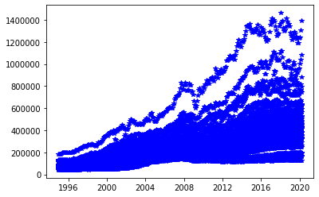

```python
price = df['Price']
borough = df[df['Borough'] == 'City of London']
date = df['Date']

plt.plot(date, price, 'b*')
plt.show()

borough.plot(kind='line', x = 'Date', y = 'Price')
plt.show()
```

[output not shown]

To limit the number of data points you have, you might want to extract the year from every month value your *Month* column.

To this end, you *could* apply a *lambda function*. Your logic could work as follows:

1. look through the `Month` column
2. extract the year from each individual value in that column
3. store that corresponding year as separate column.

Whether you go ahead with this is up to you. Just so long as you answer our initial brief: which boroughs of London have seen the greatest house price increase, on average, over the past two decades?

```python
df['Date'].head()

df['Year'] = df['Date'].dt.year #.apply(lambda t: t.year) #<--lambda method (suggested method), also works
df.head()
#df.dtypes
```

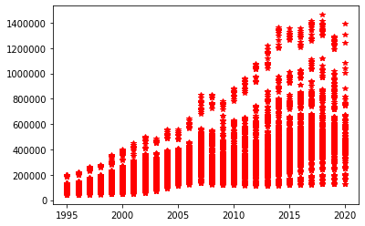

```python
year = df['Year']
plt.plot(year, price, 'r*')
plt.show()
```

```python
df_group = df.groupby(['Borough','Year']).mean()
#print(df_group.loc['City of London'])
df_group.head(30)
#df_group.dtypes
#print(df_group)
#df_group['Price'].head()

#df_selectedYears = df.loc[df['Year'] == 1995].append(df.loc[df['Year'] == 2020])
df1995 = df.loc[df['Year'] == 1995]  #used lowest prices
df1995 = df1995.reset_index(drop=True)
df2019 = df.loc[df['Year'] == 2018]  #switched to 2018 upon examination of above plot since 2018 has highest values than 2019/20, ultimately did not make a difference in the borough, but price diff was more significant
df2019 = df2019.reset_index(drop=True)

#df1995.head(50)
#df2019.tail(50)

df_priceDiff = pd.concat([df1995['Price'], df2019['Price']], axis=1)
df_priceDiff = pd.concat([df1995['Borough'], df_priceDiff], axis=1)
colName = ['Borough', 'Price 1995', 'Price 2019']
df_priceDiff.columns = colName
df_priceDiff['Price Difference'] = (df_priceDiff['Price 2019'].subtract(df_priceDiff['Price 1995']))
#df_priceDiff = df2020['Price'].subtract(df1995['Price'], fill_value=0)
#df1995.dtypes

#print(df1995['Borough'])
#print(df2020['Borough'])
print(df_priceDiff)

plt.plot(df_priceDiff['Borough'], df_priceDiff['Price Difference'], 'b*')
plt.show()

maxrow = df_priceDiff.iloc[df_priceDiff['Price Difference'].idxmax()]  #dfrm.iloc[dfrm['A'].idxmax()]
maxval = max(df_priceDiff['Price Difference'])
print('the greatest increase in price was ' + str(maxval) + ' and occurred in ' + str(maxrow['Borough']))
```

[output not shown]

```
                Borough   Price 1995    Price 2019  Price Difference
0        City of London  91448.98487  802128.85280      710679.86793
1    Barking & Dagenham  50460.22660  291547.85900      241087.63240
2                Barnet  93284.51832  531832.19760      438547.67928
3                Bexley  64958.09036  342095.70830      277137.61794
4                 Brent  71306.56698  493882.35390      422575.78692
..                  ...          ...           ...               ...
535     EAST OF ENGLAND  55523.84244  290885.66326      235361.82082
536              LONDON  75177.55688  473454.32262      398276.76574
537          SOUTH EAST  64260.60262  321264.82936      257004.22674
538          SOUTH WEST  53081.17112  256811.90106      203730.72994
539             England  52921.61570  246518.47281      193596.85711

[540 rows x 4 columns]
```

**3. Modeling**

Consider creating a function that will calculate a ratio of house prices, comparing the price of a house in 2018 to the price in 1998.

Consider calling this function create_price_ratio.

You’d want this function to:

1. Take a filter of dfg, specifically where this filter constrains the London_Borough, as an argument. For example, one admissible argument should be: dfg[dfg[‘London_Borough’]==‘Camden’].
2. Get the Average Price for that Borough, for the years 1998 and 2018.
3. Calculate the ratio of the Average Price for 1998 divided by the Average Price for 2018.
4. Return that ratio.

Once you’ve written this function, you ultimately want to use it to iterate through all the unique London_Boroughs and work out the ratio capturing the difference of house prices between 1998 and 2018.

Bear in mind: you don’t have to write a function like this if you don’t want to. If you can solve the brief otherwise, then great!

```python
#df_group.dtypes
#df_group.loc['City of London'].Price.iloc[24] #0-1995 24-2019

def create_price_ratio(df = df_group, Borough = 'City of London'):
    Bor = str(Borough)
    d2019 = df.loc[Bor].Price.iloc[24]
    d1995 = df.loc[Bor].Price.iloc[0]
    pRatio = float(d2019/d1995)
    return pRatio

#create_price_ratio(df_group, 'City of London')
```

```python
priceRatios = {}

for place in df_priceDiff['Borough'].unique():
    priceRatios[place] = create_price_ratio(df_group, place)
#print(priceRatios)

df_priceRatios = pd.DataFrame(priceRatios.items())
#print(df_priceRatios)
maxratinfo = df_priceRatios.iloc[df_priceRatios.iloc[:,1].idxmax()]

print('the max housing price ratio was '+str(maxratinfo[1])+' and occurred in '+str(maxratinfo[0]))
```

```
the max housing price ratio was 8.41589402978886 and occurred in Hackney
```

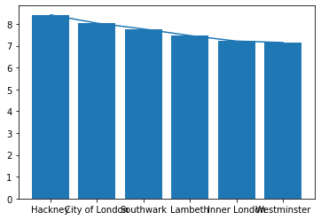

```python
df_pR_sort = df_priceRatios.sort_values(by = 1, ascending=False )
#print(df_pR_sort)
nn = 6
bour = df_pR_sort.iloc[:,0].head(nn)
rat = df_pR_sort.iloc[:,1].head(nn)
plt.bar(bour, height = rat)
plt.plot(bour, rat)
plt.show()

print(df_pR_sort.head(nn))
```

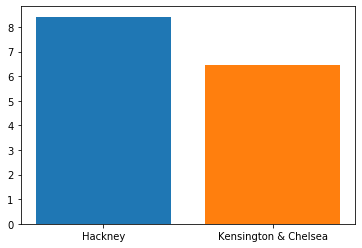

```python
phackney = df_pR_sort.iloc[0,1]
pkinsingtonChelsea = df_pR_sort.iloc[15,1]
hackney = df_pR_sort.iloc[0,0]
kinsingtonChelsea = df_pR_sort.iloc[15,0]

plt.bar(hackney, phackney)
plt.bar(kinsingtonChelsea, pkinsingtonChelsea)
plt.show()


phackney = df_priceDiff[df_priceDiff['Borough'] == 'Hackney']['Price Difference']
hackney = df_priceDiff[df_priceDiff['Borough'] == 'Hackney']['Borough']
kc = df_priceDiff[df_priceDiff['Borough'] == 'Kensington & Chelsea']['Borough']
pkc = df_priceDiff[df_priceDiff['Borough'] == 'Kensington & Chelsea']['Price Difference']

plt.plot(hackney, phackney, 'b*')
plt.plot(kc, pkc, 'r*')
plt.show()
```

[output not shown]

### Conclusion

Interpret the analysis so **everyone** can understand!

#### What can you conclude?

numerical example with higher spread: 9/4 = 2.25 9-4 = 5

numerical example with higher ratio: 6/2.5 = 2.4 6-2.5 = 3.5

Thus, in my analysis I found that the borough of Hackney had the highest ratio of 8.42, while the highest price difference occurred in Kensington & Chelsea at 1,280,682. Visualization of the data was very helpful for making these inferences.

#### Look back at your notebook. Think about how you might summarize what you have done, and prepare a quick presentation on it to your mentor at your next meeting.

https://docs.google.com/presentation/d/18x9hFMjn02snargMePwxdUdHXlBmiI61UAo36LIr4XY/edit?usp=sharing

[output not shown]